# Behind the Curtain: Statistical Insights into Movie Success

Author

Cheng Tang, Mingcan Wang, Yiang Liang, Yuxuan Zhao, Zilu Wang

# 1 Introduction

In the evolving landscape of cinematic entertainment, the question of what factors lead a film to be favorably received by audiences has intrigued producers, directors, and marketers alike. This project, titled “Behind the Curtain: Statistical Insights into Movie Success” embarks on a statistical journey to decipher the complex dynamics between various film attributes and their resulting viewer ratings, specifically focusing on the critical threshold of a rating above 7, often considered a benchmark for success in the industry.

The inception of this analysis is rooted in the premise that a film’s length, budget, viewer engagement (measured through votes), and genre hold significant sway over its overall reception. Traditionally, the entertainment industry has relied on anecdotal evidence or isolated case studies to gauge the potential success of film projects. However, in the age of data-driven decision-making, this project leverages a Generalized Linear Model (GLM) to systematically evaluate these factors, offering a more empirical basis for understanding cinematic success.

Our dataset comprises diverse films spanning various years, genres, and production scales, enabling a comprehensive analysis that transcends specific market trends or cultural biases. By employing a logistic regression framework, we aim to predict the likelihood of a film achieving a rating above 7, transforming subjective notions of quality and appeal into quantifiable probabilities. The selection of variables such as ‘length’, ‘budget’, and ‘votes’ is predicated on the hypothesis that these factors collectively encapsulate elements of narrative compactness, production quality, and audience engagement—each a potential predictor of a film’s rating.

As we navigate through this project, our goal is to distill actionable insights that can guide filmmakers and studios in crafting content that resonates with viewers. Beyond its immediate application, this study contributes to the broader discourse on the quantification of artistic and entertainment value, marking a confluence of creativity and analytics.

# 2 Methodology

The methodology of the project involves a systematic approach to understanding the factors contributing to movie success, as measured by audience ratings. Initially, the data is cleansed and preprocessed, which includes handling missing values and transforming skewed distributions through log transformations for variables such as film length and votes to achieve distributions closer to normal.

Gn extensive Exploratory Data Analysis (EDA) is conducted to gain deeper insights into the data’s underlying patterns and relationships. This includes examining the distributions of key variables, identifying outliers, and assessing potential correlations.

The analysis then employs a Generalized Linear Model (GLM), specifically logistic regression, to examine the influence of various film attributes—namely, length, budget, viewer engagement (votes), and genre—on the likelihood of a film receiving a rating above 7, which is considered indicative of success. The model’s predictive power and fit are assessed through accuracy, sensitivity, specificity, and the Area Under the Receiver Operating Characteristic (ROC) Curve (AUC) metrics.

To fine-tune the model, a series of candidate thresholds for classification are evaluated to identify the optimal balance between sensitivity and specificity. This involves calculating performance metrics across different threshold values and selecting the one that provides the best compromise according to the project’s objectives.

The methodology also encompasses residual analysis to evaluate the model’s assumptions and the fit to the data, ensuring the reliability and validity of the findings. Finally, based on the insights gained from the EDA and GLM analysis, strategic recommendations are formulated to guide filmmakers and producers in aligning their projects with the attributes associated with higher-rated films.

# 3 Exploratory Data Anlaysis

**Overview**

```
Rows: 2,387
Columns: 8
$ film_id <int> 39891, 33810, 20282, 33131, 50633, 37020, 55337, 28037, 13291,…
$ year    <int> 2003, 2004, 1941, 1959, 1917, 1934, 2003, 1988, 1981, 1935, 19…
$ length  <int> 75, 120, 78, 106, 70, 64, 91, 101, 78, 7, 21, 90, 99, 101, 110…
$ budget  <dbl> 10.9, 19.6, 11.7, 12.0, 14.8, 11.6, 12.6, 10.1, 14.2, 6.6, 10.…
$ votes   <int> 17, 21, 14, 14, 9, 8, 182, 274, 61, 10, 5, 8, 349, 24, 20168, …
$ genre   <fct> Action, Documentary, Action, Drama, Drama, Drama, Comedy, Acti…
$ rating  <dbl> 4.4, 7.3, 2.7, 4.9, 5.6, 4.7, 4.4, 4.3, 4.3, 8.8, 7.3, 8.3, 7.…
$ above_7 <fct> 0, 1, 0, 0, 0, 0, 0, 0, 0, 1, 1, 1, 1, 1, 0, 0, 0, 1, 0, 1, 1,…
```

Statistical Summary

```
    film_id           year          length           budget
 Min.   :   33   Min.   :1894   Min.   :  1.00   Min.   : 2.10
 1st Qu.:14799   1st Qu.:1958   1st Qu.: 74.00   1st Qu.:10.00
 Median :30259   Median :1984   Median : 90.00   Median :12.00
 Mean   :29942   Mean   :1977   Mean   : 81.75   Mean   :11.95
 3rd Qu.:44670   3rd Qu.:1998   3rd Qu.:100.00   3rd Qu.:13.90
 Max.   :58780   Max.   :2005   Max.   :399.00   Max.   :23.70

     votes                genre         rating      above_7
 Min.   :     5   Action     :698   Min.   :0.700   0:1546
 1st Qu.:    12   Animation  :165   1st Qu.:3.700   1: 841
 Median :    32   Comedy     :582   Median :4.700
 Mean   :   659   Documentary:136   Mean   :5.414
 3rd Qu.:   118   Drama      :684   3rd Qu.:7.800
 Max.   :103854   Romance    : 16   Max.   :9.200
                  Short      :106
```

**Outliers**

```
                          length      budget     votes
Proportion of Outliers 0.1805614 0.004608295 0.1625471
```

**Outliers after log transformation**

```
                       length_log  votes_log
Proportion of Outliers  0.1818182 0.03812317
```

**Numerical variable distribution (Histogram)**

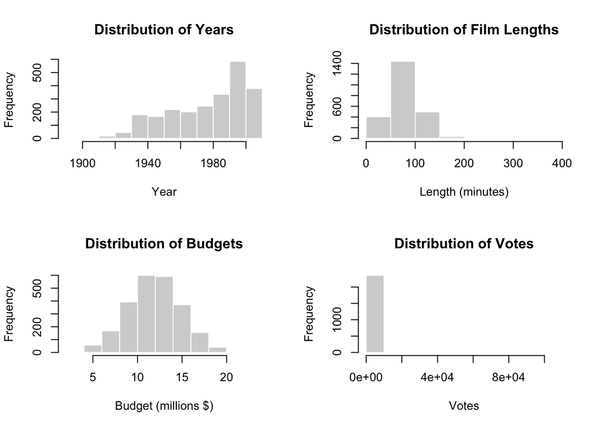

**Numerical variable distribution after log (Histogram)**

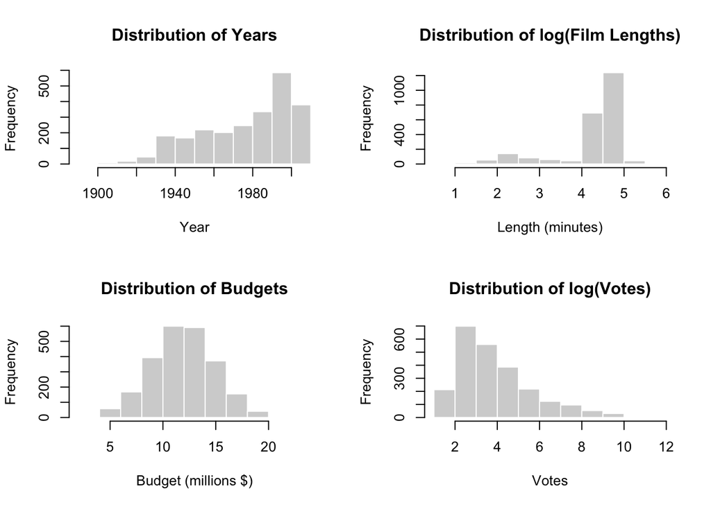

**Numerical variable distribution (Boxplot)**

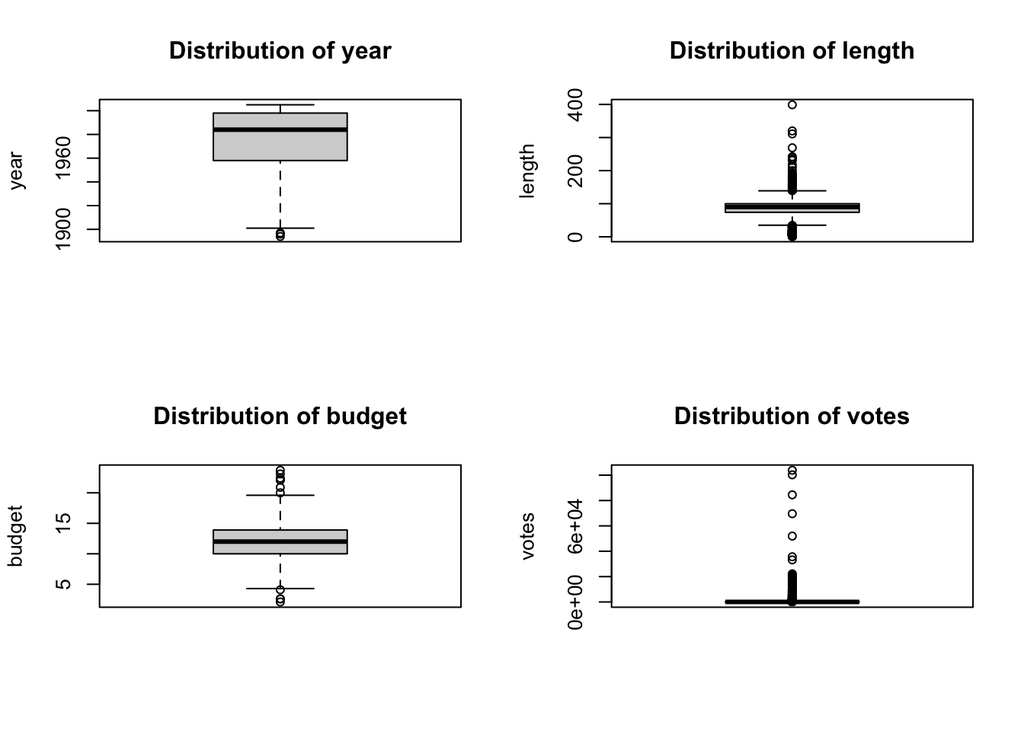

**Count plot of categorical variables**

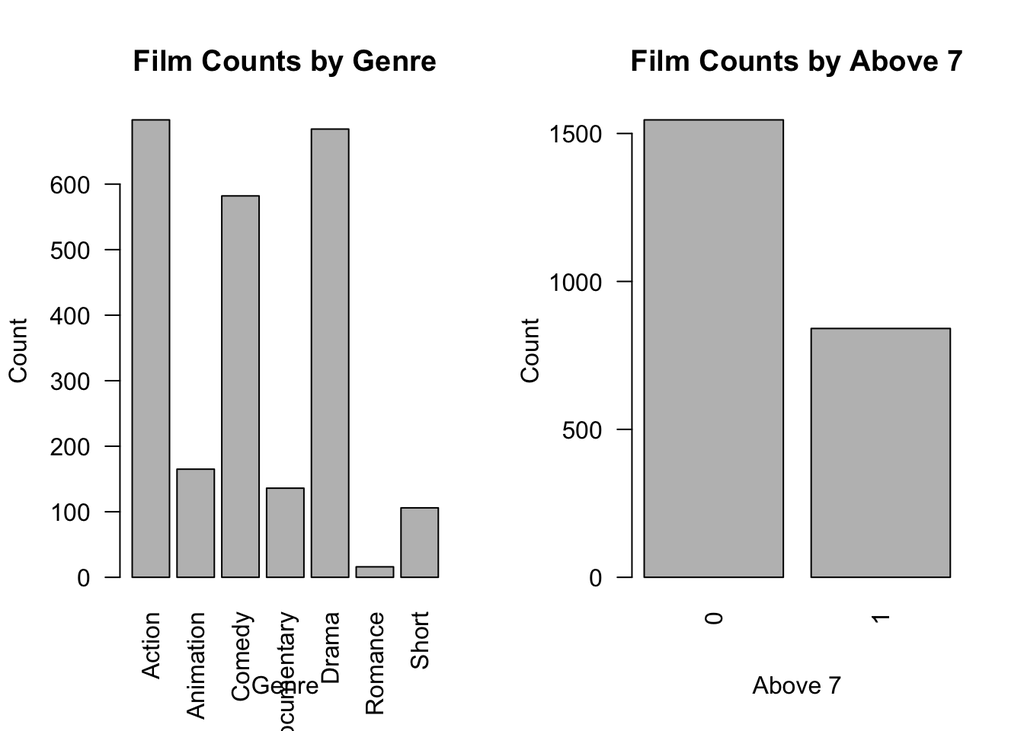

**Pairplot**

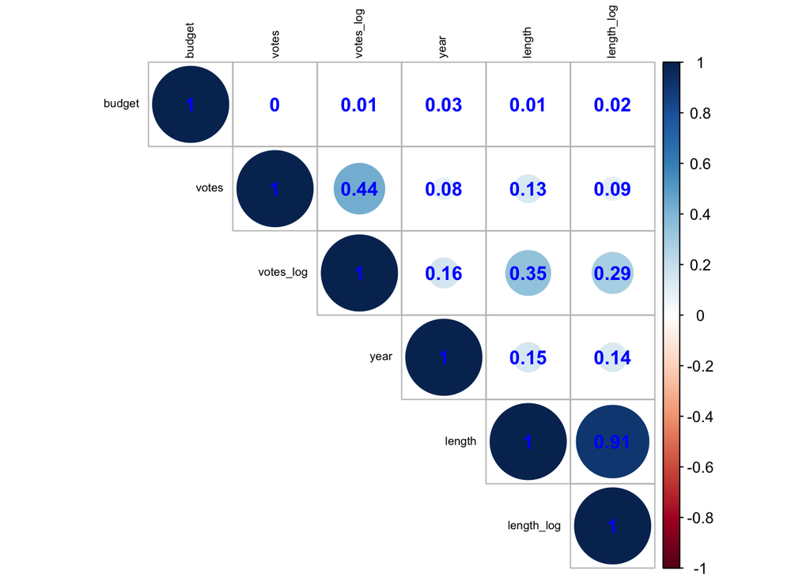

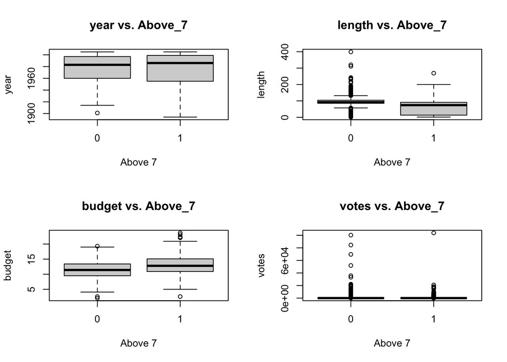

Proportion of ratings above 7 by genre

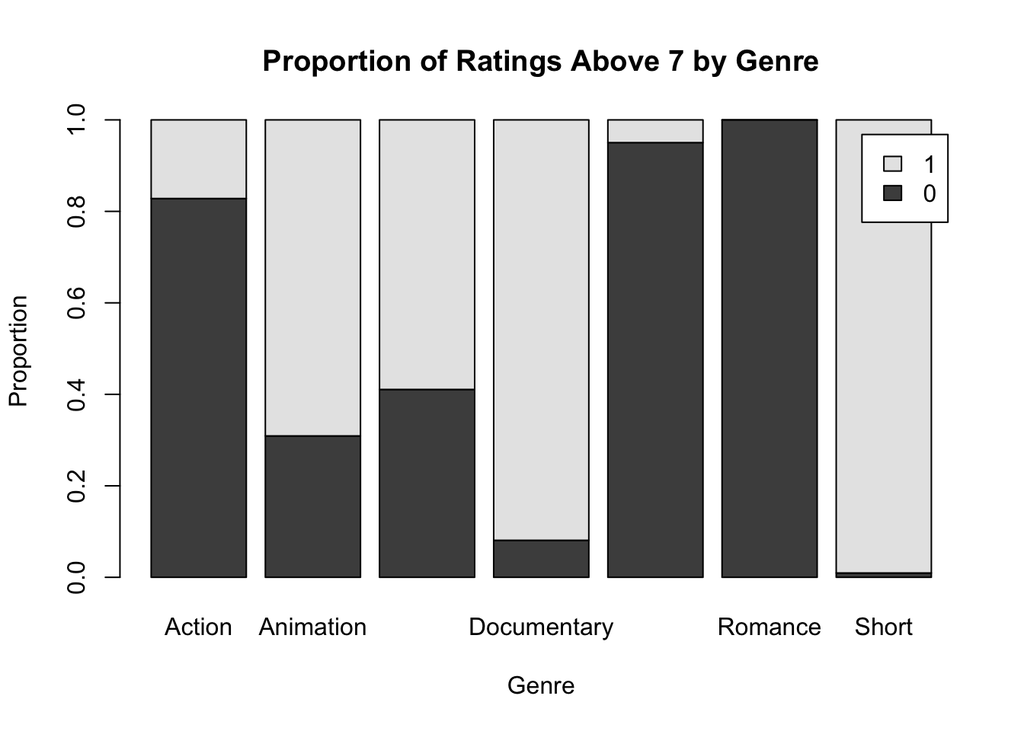

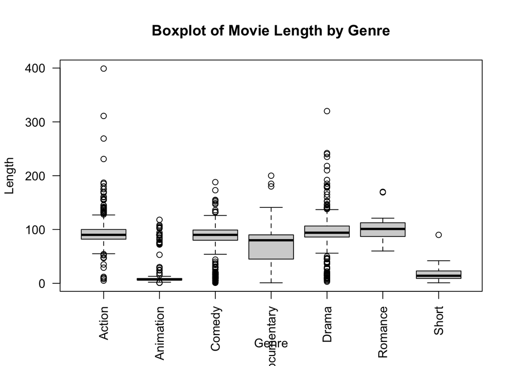

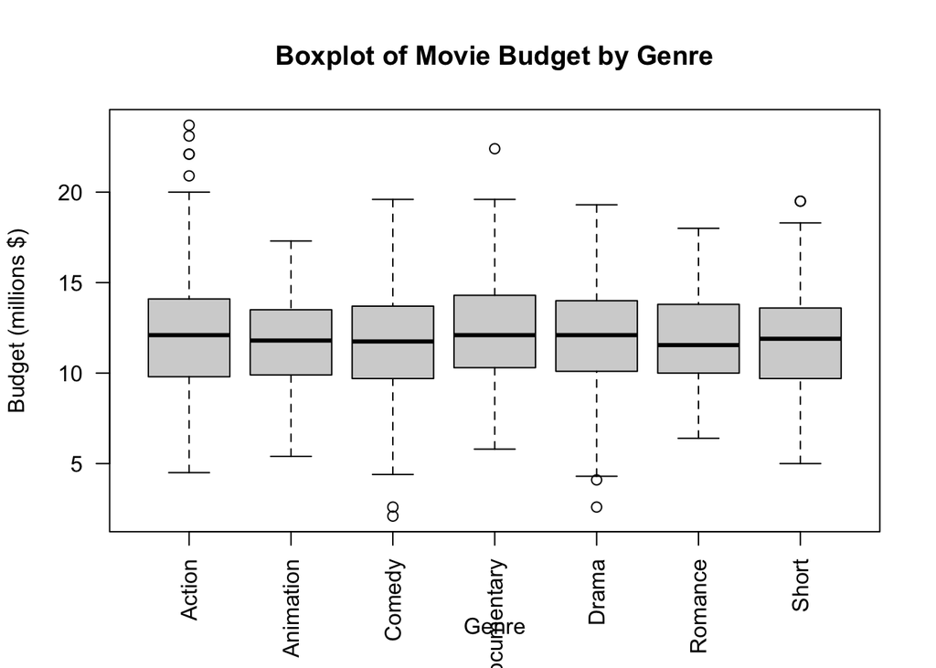

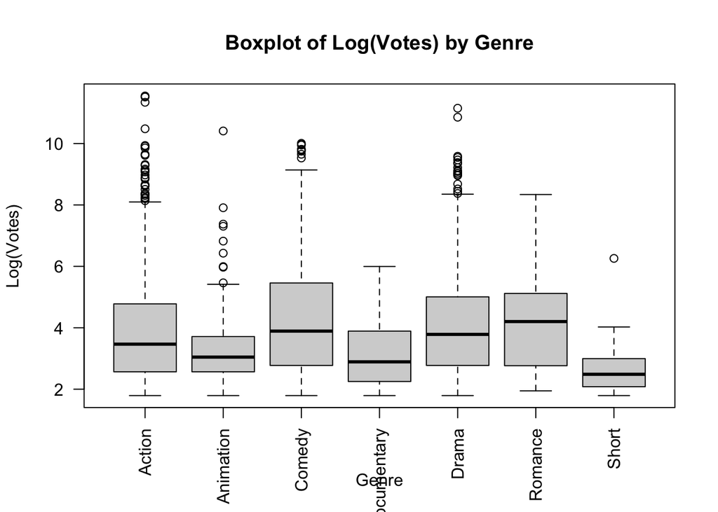

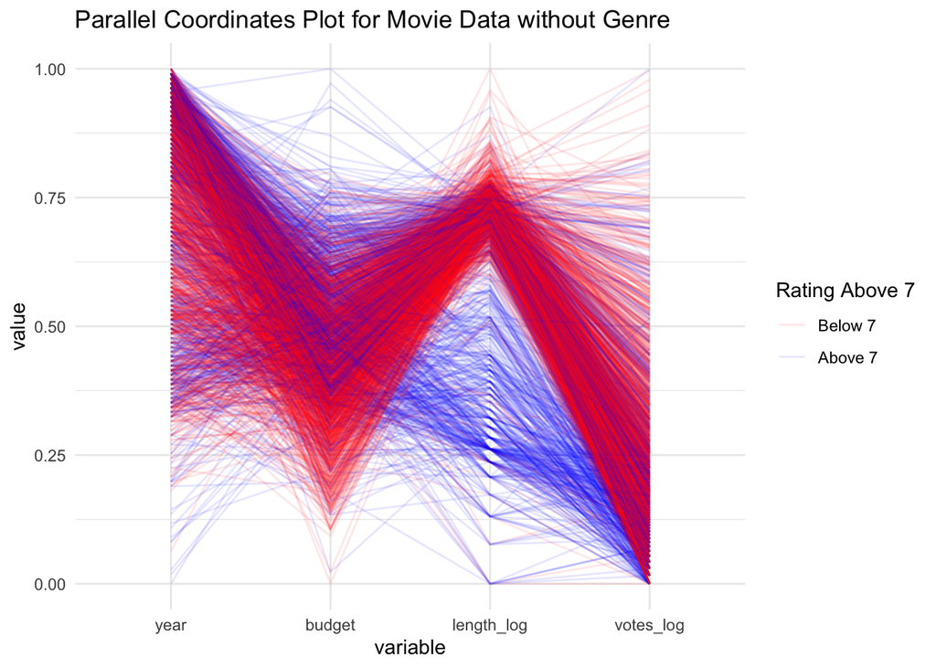

## 3.1 EDA findings

In our exploratory data analysis, we observed distinct patterns within our film dataset. The length of films is right-skewed, with most under 100 minutes, but exceptions extending up to 399 minutes. Conversely, budgets appear nearly normally distributed, indicating diverse financial investments across films. The ‘votes’ distribution is significantly right-skewed, highlighting a disparity in viewer engagement.

After log transformations, the distributions of ‘length’ and ‘votes’ approached closer to normality but still exhibited skewness. The dataset predominantly features action, drama, and comedy genres, with fewer romantic and short films. Notably, only 35% of movies are rated above 7.

# 4 Formal Analysis

## 4.1 Find Optimal Threshold for GLM

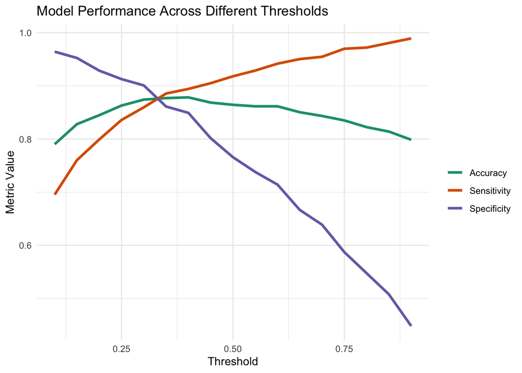

Based on the graph, we decide to set threshold to 0.32 for best balance of accuracy, sensitivity, and specificity.

## 4.2 Model Building

```r
# Define more models
# Full Model with Log Transformation
glm_model_log <- glm(above_7 ~ year + length_log + budget + votes_log + genre,
                     family = binomial, data = train_data)

# Model without Year
glm_model_no_year <- glm(above_7 ~ length_log + budget + votes_log + genre,
                        family = binomial, data = train_data)

# Model without Year and Votes_log
glm_model_no_year_votes <- glm(above_7 ~ length_log + budget + genre,
                               family = binomial, data = train_data)
# Model without Year and length
glm_model_no_year_length <- glm(above_7 ~ votes_log + budget + genre,
                               family = binomial, data = train_data)
```

## 4.3 Model Selection

```
                              Accuracy Sensitivity Specificity    AUC       BIC
Full Model                      0.8727      0.8683      0.8810 0.9372 1007.1164
Full model with Log             0.8825      0.8812      0.8849 0.9405  948.7532
Model without Year              0.8853      0.8855      0.8849 0.9413  942.5078
Model without Year and Votes    0.8937      0.8898      0.9008 0.9405  941.4027
Model without Year and Length   0.8503      0.8531      0.8452 0.9009 1192.5274
```

Based on the summary table, we will choose the fourth model due to highest accuracy, sensitivity, specificity, and lowest BIC.

## 4.4 Summary of Best Model

```
Call:
glm(formula = above_7 ~ length_log + budget + genre, family = binomial,
    data = train_data)

Coefficients:
                  Estimate Std. Error z value Pr(>|z|)
(Intercept)        3.66547    1.07287   3.416 0.000634 ***
length_log        -2.79886    0.24870 -11.254  < 2e-16 ***
budget             0.54983    0.03966  13.865  < 2e-16 ***
genreAnimation    -1.61972    0.59253  -2.734 0.006265 **
genreComedy        2.66538    0.21699  12.283  < 2e-16 ***
genreDocumentary   4.77889    0.46931  10.183  < 2e-16 ***
genreDrama        -2.54760    0.36048  -7.067 1.58e-12 ***
genreRomance     -13.95741  432.52053  -0.032 0.974257
genreShort         3.60198    1.08387   3.323 0.000890 ***
---
Signif. codes:  0 '***' 0.001 '**' 0.01 '*' 0.05 '.' 0.1 ' ' 1

(Dispersion parameter for binomial family taken to be 1)

    Null deviance: 2169.73  on 1671  degrees of freedom
Residual deviance:  874.61  on 1663  degrees of freedom
AIC: 892.61

Number of Fisher Scoring iterations: 14
```

## 4.5 Model Interpretation and Assessment

### 4.5.1 Interpretation

1. **Length of Movies (length_log)**: There is a significant negative relationship between the log-transformed length of movies and their likelihood of being rated above 7. This suggests that longer movies are less likely to receive high ratings, potentially indicating viewer preferences for shorter films or perhaps an association with certain film types or genres that are longer but less popular.
2. **Budget (budget)**: The budget of a movie shows a significant positive association with the likelihood of being rated above 7. This might imply that higher-budget movies, which can afford better production quality, actors, and marketing, are more likely to be well-received by audiences.
3. **Genre Differences**:
   - **Animation and Drama**: Compared to the baseline genre, animation and drama films are significantly less likely to be rated above 7.
   - **Short and Documentary**: These genres show a significant positive association with higher ratings, suggesting they are generally well-received or cater to specific audience segments that rate them favorably.
   - **Romance**: These genres do not show significant effects, possibly due to a smaller sample size, less variation in ratings, or other model limitations.